# Lab 6 Solutions

## Exercise 1

```r
performance_lm_additive <- lm(performance ~ size + females +
                       diversity + testosterone,
                     data = team_data)
summary(performance_lm_additive)
```

```
##
## Call:
## lm(formula = performance ~ size + females + diversity + testosterone,
##     data = team_data)
##
## Residuals:
##     Min      1Q  Median      3Q     Max
## -2.7476 -0.3824  0.1728  0.5123  1.3270
##
## Coefficients:
##               Estimate Std. Error t value Pr(>|t|)
## (Intercept)  -0.882992   0.923607  -0.956   0.3424
## size          0.310637   0.181743   1.709   0.0919 .
## females      -0.425697   0.232094  -1.834   0.0709 .
## diversity    -0.326054   1.173580  -0.278   0.7820
## testosterone  0.002356   0.003955   0.596   0.5533
## ---
## Signif. codes:  0 '***' 0.001 '**' 0.01 '*' 0.05 '.' 0.1 ' ' 1
##
## Residual standard error: 0.8223 on 69 degrees of freedom
## Multiple R-squared:  0.0911, Adjusted R-squared:  0.03841
## F-statistic: 1.729 on 4 and 69 DF,  p-value: 0.1535
```

$\widehat{\text{performance}} = -0.88 + 0.31 \text{size} - 0.43 \text{females} - 0.33 \text{diversity} + 0.002 \text{testosterone}$

$R^2_{adj} = 0.038$

## Exercise 2

$R^2 = 0.091$. We have $R^2_{adj} < R^2$ because the adjusted coefficient of determination accounts for the number of parameters in the model. Since $R^2$ never decreases when we add parameters, it is useful that $R^2_{adj}$ accounts for the number of parameters.

## Exercise 3

The model in equation 1 assumes that the relationship between diversity and group performance (i.e., the slope on diversity) is the same for any fixed level of testosterone. If we want to allow the relationship between diversity and group performance to vary for different levels of testosterone, then we need to use an interaction term.

## Exercise 4

```r
performance_lm <- lm(performance ~ size + females +
                       diversity*testosterone,
                     data = team_data)
summary(performance_lm)
```

```
##
## Call:
## lm(formula = performance ~ size + females + diversity * testosterone,
##     data = team_data)
##
## Residuals:
##      Min       1Q   Median       3Q      Max
## -2.81484 -0.34770  0.09641  0.44338  1.23239
##
## Coefficients:
##                        Estimate Std. Error t value Pr(>|t|)
## (Intercept)            -8.99931    1.94474  -4.628 1.71e-05 ***
## size                    0.27770    0.16009   1.735   0.0873 .
## females                -0.34429    0.20501  -1.679   0.0977 .
## diversity              16.12690    3.72741   4.327 5.08e-05 ***
## testosterone            0.07564    0.01633   4.633 1.68e-05 ***
## diversity:testosterone -0.14796    0.03221  -4.594 1.94e-05 ***
## ---
## Signif. codes:  0 '***' 0.001 '**' 0.01 '*' 0.05 '.' 0.1 ' ' 1
##
## Residual standard error: 0.7236 on 68 degrees of freedom
## Multiple R-squared:  0.3064, Adjusted R-squared:  0.2554
## F-statistic: 6.007 on 5 and 68 DF,  p-value: 0.0001165
```

$\widehat{\text{performance}} = -9.00 + 0.28 \text{size} - 0.34 \text{females} + 16.13 \text{diversity} + 0.076 \text{testosterone} - 0.15 \text{diversity} \cdot \text{testosterone}$

$R^2_{adj} = 0.255$. We can see that $R^2_{adj}$ has increased substantially (from 0.038 to 0.255) by adding the interaction term.

## Exercise 5

```r
# when testosterone = 70 pg/mL
16.13 - 0.15*70
```

```
## [1] 5.63
```

```r
# when testosterone = 160 pg/mL
16.13 - 0.15*160
```

```
## [1] -7.87
```

Combining the terms which include diversity, the slope on diversity for fixed size, number of female group members, and testosterone is $16.13 - 0.15 \ \text{testosterone}$. So when testosterone = 70 pg/mL, the slope is 5.63, and when testosterone = 160 pg/mL, the slope is -7.87. (Note the change in sign – this supports the researchers’ hypothesis that diversity is beneficial for groups with low testosterone, but not for groups with high testosterone).

## Exercise 6

```r
predict(performance_lm,
        newdata = data.frame(size = 6, females = 2,
                             diversity = 0.6,
                             testosterone = 70),
        interval="prediction", level = 0.95)
```

```
##         fit        lwr      upr
## 1 0.7345599 -0.8051952 2.274315
```

```r
predict(performance_lm,
        newdata = data.frame(size = 6, females = 2,
                             diversity = 0.3,
                             testosterone = 160),
        interval="prediction", level = 0.95)
```

```
##        fit        lwr      upr
## 1 1.816021 0.09760455 3.534437
```

Our estimated performance for the group with high diversity and low testosterone is 0.734, and a 95% prediction interval is [-0.805, 2.274]. For the group with low diversity and high testosterone, the predicted performance is 1.816, with a 95% prediction interval of [0.098, 3.534].

## Exercise 7

$H_0: \beta_5 = 0$

$H_A: \beta_5 \neq 0$

## Exercise 8

Reduced model ( $H_0$ ): $\text{performance} = \beta_0 + \beta_1 \text{size} + \beta_2 \text{females} + \beta_3 \text{diversity} + \beta_4 \text{testosterone} + \varepsilon$

Full model ( $H_A$ ): $\text{performance} = \beta_0 + \beta_1 \text{size} + \beta_2 \text{females} + \beta_3 \text{diversity} + \beta_4 \text{testosterone} + \beta_5 \text{diversity} \cdot \text{testosterone} + \varepsilon$

## Exercise 9

```r
anova(performance_lm_additive, performance_lm)
```

```
## Analysis of Variance Table
##
## Model 1: performance ~ size + females + diversity + testosterone
## Model 2: performance ~ size + females + diversity * testosterone
##   Res.Df    RSS Df Sum of Sq      F    Pr(>F)
## 1     69 46.653
## 2     68 35.604  1     11.05 21.104 1.939e-05 ***
## ---
## Signif. codes:  0 '***' 0.001 '**' 0.01 '*' 0.05 '.' 0.1 ' ' 1
```

The test-statistic is $F = 21.1$ and the p-value is $1.9 \times 10^{-5}$. The p-value is small, so we have strong evidence that the relationship between diversity and performance depends on testosterone.

## Exercise 10

The numerator degrees of freedom (1) is the difference in the number of parameters between the full and reduced models. In this case, the only difference is the interaction term, which appears in the full model but not the reduced model. The denominator degrees of freedom (68) is the degrees of freedom for the full model, and is given by $n - p$, where $n$ is the number of observations in the data and $p$ is the number of parameters in the full model.

## Exercise 11

```r
summary(performance_lm)
```

```
##
## Call:
## lm(formula = performance ~ size + females + diversity * testosterone,
##     data = team_data)
##
## Residuals:
##      Min       1Q   Median       3Q      Max
## -2.81484 -0.34770  0.09641  0.44338  1.23239
##
## Coefficients:
##                        Estimate Std. Error t value Pr(>|t|)
## (Intercept)            -8.99931    1.94474  -4.628 1.71e-05 ***
## size                    0.27770    0.16009   1.735   0.0873 .
## females                -0.34429    0.20501  -1.679   0.0977 .
## diversity              16.12690    3.72741   4.327 5.08e-05 ***
## testosterone            0.07564    0.01633   4.633 1.68e-05 ***
## diversity:testosterone -0.14796    0.03221  -4.594 1.94e-05 ***
## ---
## Signif. codes:  0 '***' 0.001 '**' 0.01 '*' 0.05 '.' 0.1 ' ' 1
##
## Residual standard error: 0.7236 on 68 degrees of freedom
## Multiple R-squared:  0.3064, Adjusted R-squared:  0.2554
## F-statistic: 6.007 on 5 and 68 DF,  p-value: 0.0001165
```

The test statistic is $t = -4.59$, and the p-value is the same as before ( $1.9 \times 10^{-5}$ ).

## Exercise 12

```r
(-4.59)^2
```

```
## [1] 21.0681
```

$F = 21.1 = (-4.59)^2 = t^2$ (up to rounding error).

## Exercise 13

```r
t_star = qt(0.025, 68, lower.tail = F)
-0.14796 - t_star * 0.03221
```

```
## [1] -0.2122341
```

```r
-0.14796 + t_star * 0.03221
```

```
## [1] -0.08368595
```

The confidence interval is given by

$\widehat{\beta}_5 \pm t^* SE_{\widehat{\beta}_5}$

For a 95% confidence interval, our critical value is $t^* = 1.995$ (from a $t_{68}$ distribution). We are 95% confident that a one-unit increase in testosterone is associated with a change in the true slope between diversity and group performance (holding size, number of female group members, and testosterone fixed) of between -0.21 and -0.08.

## Exercise 14

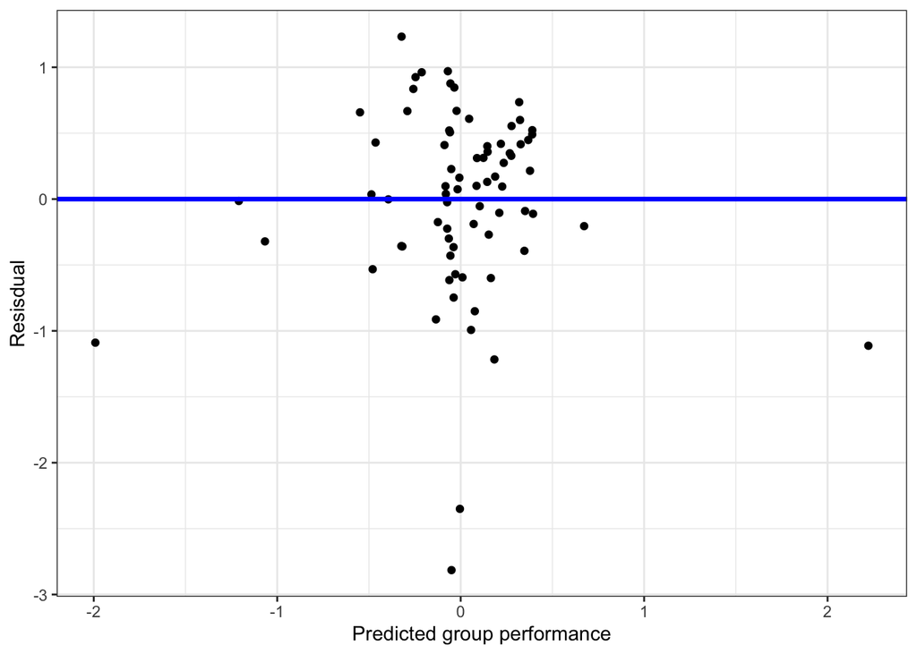

```r
team_data %>%
  mutate(pred = predict(performance_lm),
         resid = residuals(performance_lm)) %>%
  ggplot(aes(x = pred, y = resid)) +
  geom_point() +
  geom_abline(slope = 0, intercept = 0,
              color = "blue", lwd = 1.2) +
  labs(x = "Predicted group performance",
       y = "Resisdual") +
  theme_bw()
```

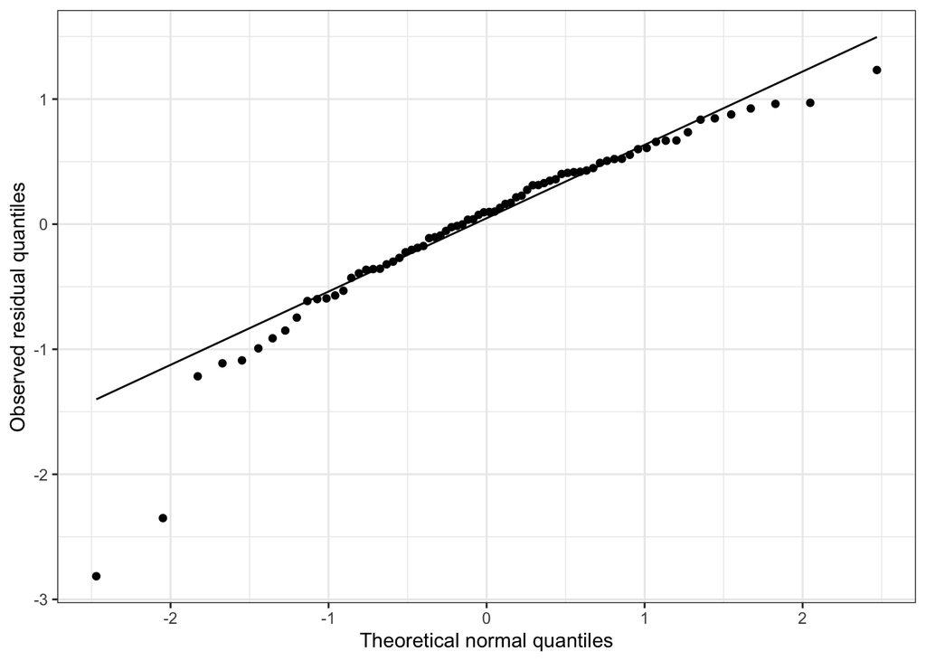

```r
team_data %>%
  mutate(resid = residuals(performance_lm)) %>%
  ggplot(aes(sample = resid)) +
  geom_qq() +
  geom_qq_line() +
  labs(x = "Theoretical normal quantiles",
       y = "Observed residual quantiles") +
  theme_bw()
```

From the residual plot and the QQ plot, the shape, constant variance, and normality assumptions appear reasonable. The points in the residual plot appear randomly scattered around 0, with no clear patter to the residuals or change in variance. In the QQ plot, the points fall close to the diagonal line.

There are two points which may be potential outliers, and which fall away from the diagonal in the left tail of the QQ plot.

## Exercise 15

The independence assumption seems reasonable. As far as I understand the paper, the final group performances are scored individually (not ranked against each other), so it is hard to see how one group’s performance could influence another’s. The randomness assumption is a little less reasonable. All groups were composed of MBA students at Columbia, so at best we could generalize to a population of graduate students at elite universities.

## Exercise 16

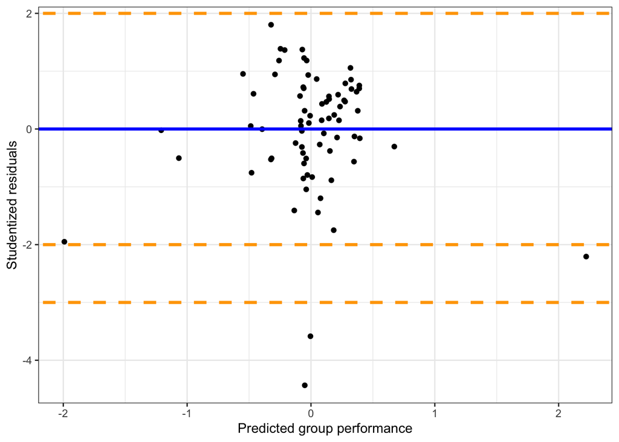

```r
team_data %>%
  mutate(pred = predict(performance_lm),
         studentized_resids = rstudent(performance_lm)) %>%
  ggplot(aes(x = pred, y = studentized_resids)) +
  geom_point() +
  geom_abline(slope = 0, intercept = 0,
              color = "blue", lwd = 1.2) +
  geom_abline(slope = 0, intercept = c(-3, -2, 2, 3),
              color = "orange", lwd = 1.2,
              lty = 2) +
  labs(x = "Predicted group performance",
       y = "Studentized residuals") +
  theme_bw()
```

There are two potential outliers with studentized residuals below -3.

## Exercise 17

```r
team_data_new <- team_data %>%
  mutate(studentized_resids = rstudent(performance_lm)) %>%
  filter(studentized_resids > -3, studentized_resids < 3)

performance_lm_additive_new <- lm(performance ~ size + females +
                       diversity + testosterone,
                     data = team_data_new)

performance_lm_new <- lm(performance ~ size + females +
                       diversity*testosterone,
                     data = team_data_new)

summary(performance_lm_new)
```

```
##
## Call:
## lm(formula = performance ~ size + females + diversity * testosterone,
##     data = team_data_new)
##
## Residuals:
##      Min       1Q   Median       3Q      Max
## -1.37495 -0.35633  0.05792  0.37868  1.08754
##
## Coefficients:
##                        Estimate Std. Error t value Pr(>|t|)
## (Intercept)            -9.45391    1.53791  -6.147 5.15e-08 ***
## size                    0.23709    0.12671   1.871   0.0658 .
## females                -0.25308    0.16252  -1.557   0.1242
## diversity              17.36072    2.95197   5.881 1.49e-07 ***
## testosterone            0.07854    0.01290   6.088 6.53e-08 ***
## diversity:testosterone -0.15481    0.02546  -6.081 6.70e-08 ***
## ---
## Signif. codes:  0 '***' 0.001 '**' 0.01 '*' 0.05 '.' 0.1 ' ' 1
##
## Residual standard error: 0.5713 on 66 degrees of freedom
## Multiple R-squared:  0.4209, Adjusted R-squared:  0.377
## F-statistic: 9.592 on 5 and 66 DF,  p-value: 6.494e-07
```

```r
t_star = qt(0.025, 66, lower.tail = F)
-0.15481 - t_star * 0.02546
```

```
## [1] -0.2056425
```

```r
-0.15481 + t_star * 0.02546
```

```
## [1] -0.1039775
```

Our p-value is now $6.7 \times 10^{-8}$, and the 95% confidence interval is (-0.21, -0.10) (note how the degrees of freedom changes in the computation – we removed two points, so $n$ has decreased by 2). While our estimate of $\beta_5$ has changed slightly, our conclusion is still the same: there is strong evidence that the relationship between diversity and group performance depends on the level of testosterone.